# Mesures de similarité dans un graphe d’interactions protéiques

## Introduction

Toutes les cellules eucaryotes utilisent l'autophagie pour recycler les protéines et les organelles, assurant ainsi un contrôle de qualité au niveau infra-cellulaire, et une homéostasie et la survie de la cellule.

L'autophagie regroupe plusieurs voies de dégradation lysosomale des constituants cellulaires, essentielles à l’homéostasie cellulaire. Dans les cellules eucaryotes ce mécanisme se trouve dans le cytosol et est associé au réticulum endoplasmique. Les protéines sont marquées pour la dégradation par une protéine appelée ubiquitine. Les composants cytosoliques indésirables sont dirigés, à travers le cytosol, vers le compartiment lytique (lysosomes ou vacuole) de dégradation et de recyclage de ses composants.

Des recherches approfondies à l’aide de levures unicellulaires et d'autres organismes modèles ont conduit à l’identification de plusieurs gènes qui sont requis pour les étapes distinctes de macro-autophagie.

Afin de décrire de l'autophagie de façon systémique, nous allons utiliser un réseau d’interactions de gènes («AXAN»), centré sur la problématique de de l'autophagie utilisant une base de donnée. Il résulte de la fusion de divers ensembles de données primaires permettant de suspecter l'implication de gènes dans l'autophagie, et des données d’interaction de ces gènes.

Les composantes du réseau qui en résultent seront analysées dans notre TP, par exemple les mécanismes principaux, les voies de signalisation, le sous-réseau de transcription et les récepteurs de l'autophagie.

### Intérêt biologique et thérapeutique de l'autophagie

Outre sa fonction centrale physiologiques (faciliter l’homéostasie cellulaire des cellules souches), l'autophagie a été reconnue comme une voie de signalisation décisive pour diverses maladies humaines telles que la neuro-dégénérescence, le cancer et les maladies inflammatoires, ainsi que le processus de vieillissement. L'autophagie ne sélectionne pas précisément les composants cytosoliques à recycler.

Il y a donc intérêt fort dans l'autophagie en tant que mécanisme thérapeutique, plusieurs essais cliniques étudient actuellement l’applicabilité de la modulation de l'autophagie dans le traitement des cancers (p. ex., glioblastome). **Un aspect intéressant sur le plan thérapeutique, serait la possibilité de non seulement de contrôler le degré d'autophagie, mais aussi de diriger l'autophagie chez l’humain vers certaines cibles de façon privilégiée.**

Plusieurs voies de signalisation contribuent à la régulation de l'autophagie, par exemple la voie de signalisation MTOR centrale (qui intègre la plupart des signaux en amont), la phosphoinositide 3-kinase (PI3K) de classe I et la phosphatidylinositol 3-kinase (PtdIns3K)de classe III , les protéines kinases mitogène (MAPK) et les voie de signalisation TP53/p53 (TRP53 chez les souris et rats).

Ces voies de signalisation répondent à des stimuli de stress internes ou externes tels que l’appauvrissement en acides aminés, en facteurs de croissance, ou des dommages à l’ADN et réglementent de l'autophagie par diverses étapes de phosphorylation, de modifications protéiques et des événements d'altération de la membrane.

Le travail présenté ici décrit un réseau d’interactions de gènes, qui a été construit par une fouille automatisée des ensembles de données primaires et la recherche documentaire manuelle. Le réseau d’interactions qui en résulte a été utilisé pour décrire les aspects évolutionnaire des gènes de l'autophagie et en particulier sur les catégories de gènes essentiels.

### Analyse des communautés de protéines

Dans le cours d'analyse de réseaux d’interactions protéiques, une étape essentielle est la définition d'une mesure de distance (ou de similarité) entre les protéines. Il existe une très grande diversité de métrique possibles, suivant ce que le type d'analyse souhaité. La matrice $S \in \mathbb{R}^{N \times N}$ de similarité entre les $N$ protéines du réseaux peut ensuite être utilisée pour partitionner le réseau.

Les auteurs d'AXAN ont utilisé un des algorithmes de *GLay*, un plugin de cytoscape. Ici, nous allons implémenter notre propre algorithme de calcul de similarité, basé sur *GraRep*. *GraRep* est une méthodologie pour construire un *plongement* (*embedding*) des protéines, c'est a dire associer à chaque protéine $i$ un vecteur $v_i\in\mathbb{R}^d$ qui la caractérise. Les vecteurs peuvent ensuite être comparés deux à deux pour obtenir une matrice de distance.

*GraRep* se distingue des autres méthodes par sa capacité a représenter le réseaux à plusieurs échelles simultanément. Pour cela, l'information des interactions à $n$ étapes est capturée, pour plusieurs un certain intervalle de valeurs de $n$. La figure suivante donne des exemples ou l'information à $n=1,2,3,4$ étapes est importante pour représenter la relation entre les nœuds A1 et A2 :

[figure not shown]

Les vecteurs associé à deux protéines sont similaires si elles partagent un environnement similaire, c'est a dire si elles interagissent avec les même protéines, éventuellement par le biais de protéines intermédiaires suivant la valeur de $n$.

### Déroulement du TP

#### Utilisation du notebook

Le notebook est divisé en cellules, contenant soit du texte, soit du code python. Le code python est exécuté sur un interpréteur unique avec la combinaison de touche `Ctrl`+`Entrée`.

Les questions (marquées **Q**) vous invitent à modifier le code de la cellule suivante et soulèvent des points de réflexions utiles pour votre rapport. Les cellules qui ne sont pas précédées de questions n'ont pas besoin d'être modifiées avant d'être exécutées.

Quelque raccourcis clavier utiles :

- Quelque soit le mode :
  - `Entrée` : Passer en mode édition (cadre vert),
  - `Esc` : passer en mode commande (cadre bleu),
  - `Ctrl`+`Entrée` : Executer une cellule,
  - `Shit`+`Entrée` : Executer une cellule et passer à la suivante,
  - `Alt`+`Entrée` : Executer une cellule et créer une nouvelle cellule à la suite,
  - `Ctrl`+`S` : Sauvegarder ;
- En mode commande :
  - Flèches haut et bas : se déplacer de cellule en cellule. Maintenir `Shift` pour sélectionner un intervalle,
  - `C` : copier une cellule,
  - `V` : coller une cellule,
  - `X` : couper une cellule (ou la supprimer),
  - `M` : changer la cellule en mode texte, `Y` pour remettre en python,
  - `L` : afficher les numéro de ligne.

Pour commencer, exécutez cette cellule qui importe les modules utilisés pendant le TP :

```python
# NetworkX, utilisé pour manipuler les graphes
import networkx as nx

# Numpy, utilisé pour le calcul matriciel
import numpy as np

# matplotlib, utilisé pour les graphiques
from matplotlib import pyplot as plt
# Configure matplotlib
%matplotlib inline
plt.rcParams['axes.grid']=False
plt.rcParams['figure.figsize']=[7.,7.]
plt.rcParams['image.cmap'] = 'gray_r'
plt.rcParams['image.interpolation'] = 'nearest'

# Les fonctions suivantes ont été écrites pour ce TP, afin de faciliter l'affichage et certain calculs.
from libTP.plot import plot_grid_matrices, plot_symetric_valued_matrix
from libTP.pmi import safe_log2
```

## Réseau d'exemple

Les auteurs d'AXAN ont identifié un sous-réseaux (appelé `M05`) enrichit gènes de l'autophagie.

Nous allons utiliser la plus grande composante connexe de ce réseaux comme exemple pour développer une intuition sur le fonctionnement de la méthode `GraRep`.

### Définition du réseau `M05`

Le code suivant définit les intéractions et utilise la bibliothèque `networkx` pour représenter le graph sous forme d'objet (`G`) :

```python
E = [('TP53INP2', 'GABARAPL2'), ('SEC23B', 'GABARAPL2'), ('SEC23B', 'GABARAP'),
     ('MAP1LC3B2', 'ATG10'), ('MAP1LC3B2', 'ATG3'), ('MAP1LC3B2', 'MAP1LC3B'),
     ('GABARAPL2', 'MAP1LC3A'), ('GABARAPL2', 'GABARAPL1'), ('GABARAPL2', 'ATG16L1'),
     ('GABARAPL2', 'GABARAP'), ('GABARAPL2', 'ATG4B'), ('GABARAPL2', 'ATG3'),
     ('GABARAPL2', 'MAP1LC3B'), ('GABARAPL2', 'MAP1LC3C'), ('GABARAPL2', 'ECHS1'),
     ('GABARAPL2', 'ATG7'), ('ATG4A', 'MAP1LC3A'), ('ATG4A', 'MAP1LC3B'), ('GABARAP', 'ATG4B'),
     ('GABARAP', 'MAP1LC3A'), ('GABARAP', 'GABARAPL1'), ('GABARAP', 'MAP1LC3B'),
     ('GABARAP', 'MAP1LC3C'), ('GABARAP', 'ATG7'), ('GABARAP', 'ATG12'),
     ('GABARAP', 'ATG3'), ('ATG4B', 'ATG10'), ('ATG4B', 'MAP1LC3A'), ('ATG4B', 'GABARAPL1'),
     ('ATG4B', 'MAP1LC3B'), ('ATG4B', 'ATG12'), ('ATG4B', 'ATG3'),
     ('ATG7', 'ATG10'), ('ATG7', 'MAP1LC3A'), ('ATG7', 'GABARAPL1'), ('ATG7', 'MAP1LC3C'),
     ('ATG7', 'MAP1LC3B'), ('ATG7', 'ATG12'), ('ATG7', 'ATG3'),
     ('ATG10', 'ATG5'), ('ATG10', 'ATG12'), ('ATG10', 'ATG3'), ('MAP1LC3C', 'ATG3'),
     ('MAP1LC3C', 'ATG16L1'), ('MAP1LC3C', 'ATG5'), ('ECHS1', 'ATG5'), ('MAP1LC3B', 'MAP1LC3A'),
     ('MAP1LC3B', 'ATG3'), ('MAP1LC3B', 'ATG16L1'), ('MAP1LC3B', 'ATG5'),
     ('ATG16L1', 'RAB33B'), ('ATG16L1', 'ATG5'), ('ATG16L1', 'ATG12'),
     ('ATG16L1', 'ATG3'), ('ATG12', 'ATG3'), ('ATG12', 'ATG5'), ('ATG3', 'MAP1LC3A'),
     ('ATG3', 'ATG5'), ('ATG3', 'GABARAPL1'), ('RAB33B', 'MAP1LC3A'), ('RAB33B', 'GABARAPL1'),
     ('ATG16L2', 'ATG5'), ('GABARAPL1', 'RAB1A'), ('MAP1LC3A', 'GDI1'),
     ('ATG5', 'GDI2'), ('RAB1A', 'GDI1'), ('GDI1', 'RAB9A'), ('GDI1', 'RAB24'),
     ('RAB24', 'GDI2'), ('RAB9A', 'GDI2'), ('GDI2', 'RAB11A')]

G = nx.Graph(data=E)
```

### Matrice d'adjacence

Afin utiliser les outils d'algèbre linéaire, nous allons représenter le graphe sous la forme d'une matrice d'adjacence :

$$ A[i,j]=\begin{cases} 1 & \textrm{si il existe une arrête entre les sommets }i\textrm{ et }j\\ 0 & \textrm{sinon} \end{cases} $$

La fonction [`nx.adjency_matrix`](https://networkx.github.io/documentation/networkx-1.9/reference/generated/networkx.linalg.graphmatrix.adjacency_matrix.html) peut réaliser cela pour nous. Il est nécessaire de lui passer le graph `G` ainsi qu'un ordre de sommets `V` (utilisé associer un indice numérique à chaque protéine).

Allez voir la documentation de la fonction et employez la pour calculer `A` :

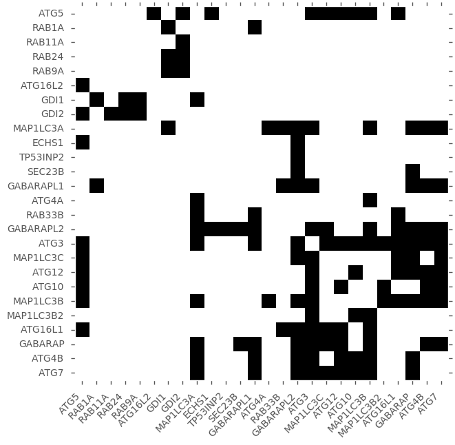

```python
V = ['ATG5', 'RAB1A', 'RAB11A', 'RAB24', 'RAB9A', 'ATG16L2', 'GDI1',
       'GDI2', 'MAP1LC3A', 'ECHS1', 'TP53INP2', 'SEC23B', 'GABARAPL1',
       'ATG4A', 'RAB33B', 'GABARAPL2', 'ATG3', 'MAP1LC3C', 'ATG12',
       'ATG10', 'MAP1LC3B', 'MAP1LC3B2', 'ATG16L1', 'GABARAP', 'ATG4B',
       'ATG7']
N = len(V)

A = nx.adj_matrix(G, nodelist=V) # TODO: retirer la correction

# Affichage :
plt.imshow(A.todense());

# Affiche les symboles des protéines sur les axes :
plt.yticks(range(len(V)), V);
plt.xticks(range(len(V)), V, rotation=45, ha='right');
```

### Matrice de transitions

Considérons l'expérience aléatoire suivante : partant d'une protéine $i$, on se déplace sur un des interactants $j$ de façon équiprobable. On apelle matrice de transition $T[i,j]$ la matrice contenant les probabilités de transition $i \rightarrow j$ pour chaque couple $(i,j)$ :

$$ T[i,j] = p(i \rightarrow j)$$

Cette probabilité dépendent donc de la présence d'une arrête entre $i$ et $j$ (un 1 dans la matrice d'adjacence $A$) et du degré de la protéine $i$.

Modifiez le code suivant pour calculer la matrice `T` à partir de `A` et de `degrees` (vecteur colone) :

```
degrés : matrix([[ 9,  2,  1,  2,  2,  1,  4,  4,  9,  2,  1,  2,  7,  2,  3, 12, 13,
          6,  7,  6, 10,  3,  7, 10,  8,  9]])
```

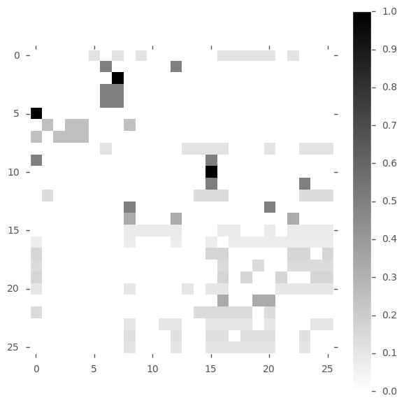

```python
degrees = A.sum(axis=1) # La somme de chaque ligne de la matrice nous donne le degré de la protéine associée
print('degrés : %r' % degrees.T)

T = A / degrees # TODO: retirer la correction

# Vérification
np.testing.assert_almost_equal(T.sum(axis=1), 1,
                               err_msg="Les lignes de T ne sont pas des vecteurs de probabilités !")
assert T.shape == (N,N)
# Affichage
plt.imshow(T)
plt.colorbar();
```

### Marches aléatoires

Lorsque l'expérience précédente est répétée $n$ fois, une marche aléatoire a $n$ transitions est obtenue.

Dans le cas d'une marche aléatoire $i \rightarrow k \rightarrow j$, la transition $i \rightarrow k$ **et** la transition $k \rightarrow j$ ont lieu. La probabilité du chemin $i \rightarrow k \rightarrow j$ est donc : $$\begin{eqnarray} p(i \rightarrow k \rightarrow j) &= p(i \rightarrow k \cap k \rightarrow j) \\ &= p(i \rightarrow k) \times p(k \rightarrow j) \\ &= T[i,k] \times T[k,j] \end{eqnarray}$$

La probabilité de passer de la protéine $i$ à $j$ avec deux transitions, quelque soit la $k$ protéine intermédiaire, est donnée par la somme : $$ \begin{eqnarray} T^2[i,j] &= p(i \xrightarrow{2} j) \\ &= \sum_k p(i \rightarrow k \rightarrow j) \\ &= \sum_k T[i,k] \times T[k,j] \\ \end{eqnarray}$$

On remarque que cela correspond au produit matriciel de la matrice $T$ avec elle même : $T^2 = T \cdot T$. Ainsi, les probabilités de transitions à $n$ étapes sont données par $T^n$, la puissance $n$ de la matrice $T$.

**Q** : Calculez les matrices pour 1 à 9 transitions, et enregistrez les dans la liste `Tns` afin de les afficher avec le code suivant :

*En python les **matrices** numpy peuvent être multipliées avec l'opérateur «**`*`**», ou la fonction `np.dot`. L'opérateur «**`*`**» produit la mutiplication élément par élément sur les **tableaux (`np.ndarray`)**, tandis que `np.dot` est la mutliplication matricielle dans les deux cas.*

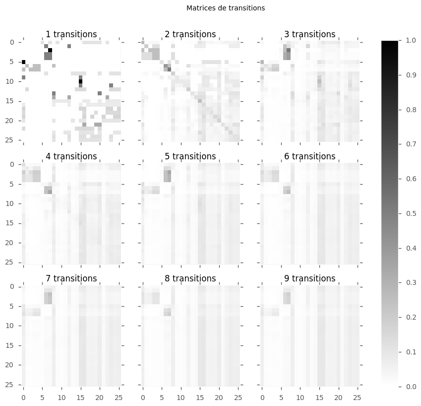

```python
Tns = [T] # Liste contenant les différentes matrices de transition pour 1 <= n <= 9

# Rajoutez ici T^2, ..., T^9 dans Tns
# TODO : retirer la correction :
for n in range(8):
    Tns.append(Tns[-1] * T)

# Vérifications
assert len(Tns) == 9
for Tn in Tns:
    assert Tn.shape == (N,N)
    np.testing.assert_almost_equal(Tn.sum(axis=1), 1,
                                   err_msg="Les lignes de T ne sont pas des vecteurs de probabilités !")

# Affichage :
plot_grid_matrices(Tns).suptitle('Matrices de transitions');
```

### Information mutuelle ponctuelle (PMI)

**Q** : Vous remarquerez que les vecteurs de probabilités de transitions (lignes de la matrice) sont de plus en plus similaires lorsque le nombre de transitions augmente. *ie.* ils dépendent de moins en moins de la protéine de départ.

- Expliquez cet effet. Quel propriété du réseau le renforce ?
  - Lorsque le nombre de transitions augmente, le point de départ importe de moins en moins. Par diffusion, les vecteurs de probabilités de transitions tendent tous vers un vecteur de probabilités stationnaire.
  - Plus le réseau est densément connecté, plus les probabilités s'homogénéisent rapidement.
- Quelle distribution de probabilité est représentée par la moyenne sur les colonnes de $T$ (vecteur ligne moyen) ?
  - C'est la probabilité marginale $p(j)$, qui décrit la probabilité de terminer la marche aléatoire en une protéine $j$ donnée, quelque soit la protéine de départ.
- Proposez une méthode pour révéler les différences entre les lignes de $T$ et la distribution moyenne. Implémentez la en modifiant la fonction `PMI` dans la cellule suivante.

**indice** : pensez au *fold change* exprimé en $\log_2$, utilisé pour mesurer les variations entre deux niveaux d'expression sur des mesures *microarrays*.

Utilisez le code suivant pour afficher le résultat :

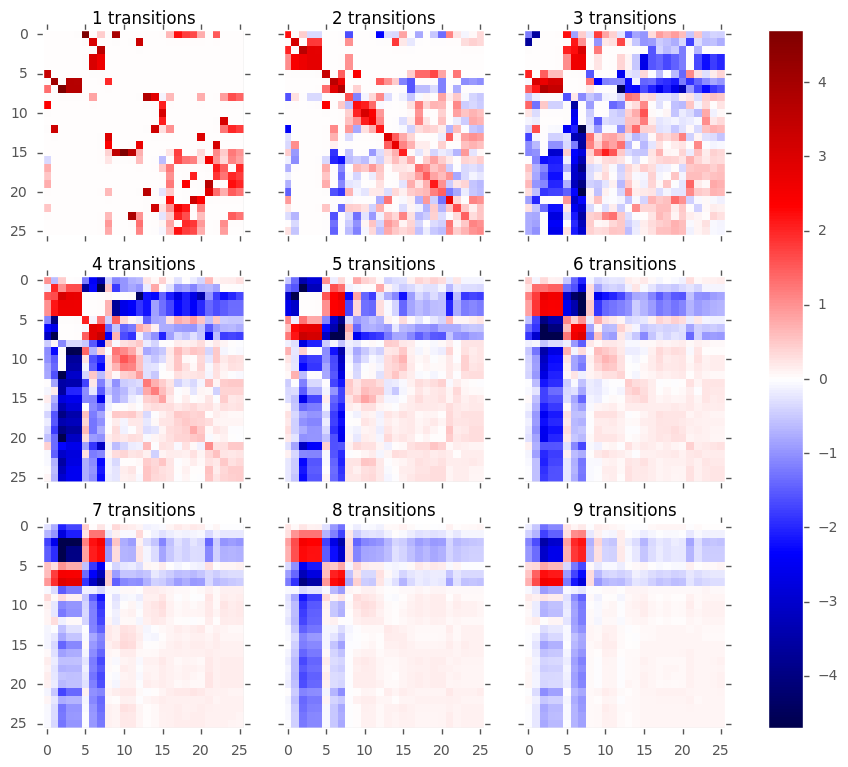

```python
def PMI(T):
    margin = T.mean(axis=0)
    #TODO : On s'attend à ce qu'ils proposent ceci : T - margin, il faut pouvoir expliquer à l'oral pourquoi la PMI est mieux
    return safe_log2(T / margin) # TODO: retirer la correction

    # Modifiez cette ligne afin révéler les différences subtiles entre les lignes de `T` et `margin` (ligne moyenne)
    return T

plot_grid_matrices([PMI(T) for T in Tns]);
```

Cette mesure locale, associée à chaque couple $(i,j)$, est appelé *Pointwise Mutual Information*. Une $PMI[i,j] > 0$ signifie qu'il est plus fréquent d'observer une marche aléatoire entre $i$ et $j$ que ne le laissent penser la probabilité d'arriver en $j$ quelque soit la protéine $i$ de départ.

### Mesure de similarité basée sur la PMI

L'environnement à $n$ transitions spécifique de chaque protéine $i$ peut être caractérisé par le vecteur ligne $PMI^{(n)}[i,:]$. Les valeurs positives sont liées aux protéines *spécifiquement* atteignables en partant de la protéine $i$.

#### Produit scalaire

Appliqué au ligne de la matrice $PMI^{(n)}$, on a donc :

$$\begin{eqnarray} sim(PMI^{(n)}[i,:],PMI^{(n)}[j,:]) &= \left\langle PMI^{(n)}[i,:] ,\, PMI^{(n)}[j,:] \right\rangle \\ &= \sum_k PMI^{(n)}[i,k] \times PMI^{(n)}[j,k] \end{eqnarray}$$

#### Similarité cosinus

Pour obtenir une valeur entre -1 et 1, nous allons diviser le produit scalaire par la norme euclidienne des deux vecteurs ligne. C'est la [similarité cosinus](https://en.wikipedia.org/wiki/Cosine_similarity) : $$ sim_{cos}(\mathbf{u},\mathbf{v}) = \frac { \left\langle \mathbf{u} ,\, \mathbf{v} \right\rangle } {\left\Vert \mathbf{u} \right\Vert_2 \cdot \left\Vert \mathbf{v} \right\Vert_2 } $$ $$ sim_{cos}(PMI^{(n)}[i,:],\,PMI^{(n)}[j,:]) = \frac { \left\langle PMI^{(n)}[i,:] ,\, PMI^{(n)}[j,:] \right\rangle } {\left\Vert PMI^{(n)}[i,:] \right\Vert_2 \cdot \left\Vert PMI^{(n)}[j,:] \right\Vert_2 } $$

#### Distance angulaire

Il est possible d'en déduire une mesure de distance : $$ dist_{cos}(\mathbf{u},\mathbf{v}) = \frac { \cos^{-1} \left( sim_{cos}(\mathbf{u},\mathbf{v}) \right) } { \pi } \simeq \frac{1 - sim_{cos}(\mathbf{u},\mathbf{v})}{2} $$

#### En pratique

Le module [`scipy.spatial.distance`](https://docs.scipy.org/doc/scipy/reference/spatial.distance.htm) contient la fonction [`pdist`](https://docs.scipy.org/doc/scipy/reference/generated/scipy.spatial.distance.pdist.html#scipy.spatial.distance.pdist) qui calcule la distance 2-à-2 entre les lignes d'une matrice. Il est possible de spécifier une métrique particulière. La métrique "cosine" correspond à la distance angulaire approximative ($1 - sim_{cos}$). Pour retrouver la similarité, on soustrait la distance à 1.

`pdist` retourne la matrice de distance sous forme compacte (il y a seulement $\frac{n(n-1)}{2}$ paires différentes). Afin d'afficher les similarités, la matrice carrée de similarité $S \in \mathbb{R}^{N \times N}$ est obtenue dans sa forme complète avec la fonction `squareform`.

**Q**: Le code ci-dessous est déjà fonctionnel. Utilisez le pour afficher la similarité basé sur l'environnement à $n$ transition, en faisant varier n.

Au besoin, dupliquer la cellule (`Esc`, `C`, `V`) pour comparer les résultats en expérimentant différentes métriques.

- Quel est l'interêt de comparer les protéines avec $n > 1$, et surtout, différents $n$ ?
  - Avec $n=1$, on ne fait que comparer les interactions immédiates des protéines. Pour $n \gg 1$, les protéines sont comparées sur leurs environnements à grande échelle dans le réseau (appartenance un module isolé par exemple) ; il n'y a plus d'informations sur les interactions locales. En utilisant la similarité à plusieurs échelles on maximise l'information extraite du réseau.

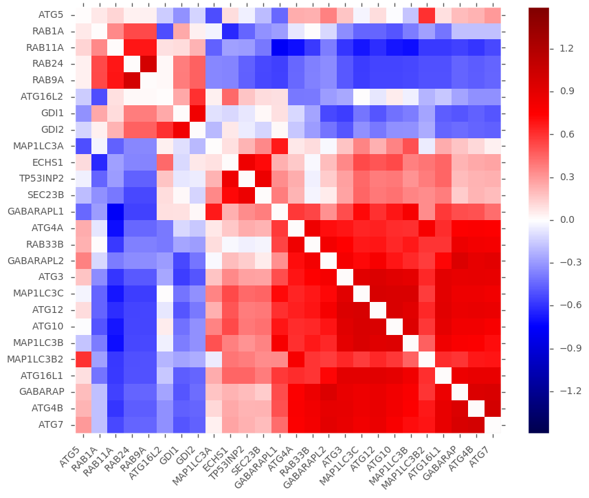

```python
from scipy.spatial import distance

Tn = Tns[2] # Similarité basé sur l'environnement à 3 transitions

S = distance.squareform(1 - distance.pdist(PMI(Tn), metric='cosine'))

plot_symetric_valued_matrix(S, labels=V)
```

#### Concaténation des sous-espaces

Afin de comparer simultanément l'environnement des protéines à $ 1 \leq n \leq 9$ transitions, les colonnes des matrices $PMI^{(n)}$ sont concaténées :

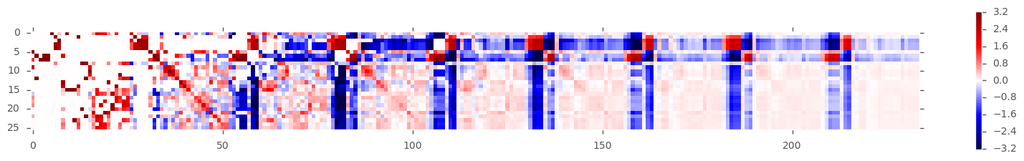

```python
PMIs = np.hstack(PMI(Tn) for Tn in Tns)
plot_symetric_valued_matrix(PMIs, figsize=(20,2.5))
```

**Q** : Copiez la cellule qui affiche les similarités cosinus, et modifiez la afin d'afficher les similarités obtenues avec la matrice concaténée `PMIs`.

- En utilisant cette méthode, le nombre maximal de transitions est un paramètre de l'algorithme. Quel biais a-t-on si on utilise un nombre élevé de transitions ?
  - Les matrices PMI sont de plus en plus similaires quand le nombre de transitions devient élevé: les probabilités tendent vers l'état stationnaire. La mesure de similarité est donc biaisée vers cet état stationnaire, limitant ainsi l’influence des marches aléatoires à 1,2 ou 3 transitions.
- Proposez une ébauche de méthode pour pondérer les matrices et éviter ce biais.
  - Une solution est de pondérer individuellement les matrices avec un poid exponentiellement décroissant. On peut prendre la suite géométrique $w_n=\lambda_2^n$, où $\lambda_2$ est la seconde plus grande valeur propre de la matrice $T$. L'information mutuelle $MI(I,J)$ suit également une progression géométrique de raison similaire.
  - Une autre solution est d'utiliser les différents sous-espaces indépendamment, avec une approche multi-échelle. Par exemple il est envisageable de réaliser un partitionnement hiérarchique avec la matrice PMI des marches aléatoires les plus longues, puis de re-partitionner les clusters obtenus en enlevant une étape a la marche aléatoire, et ainsi de suite.

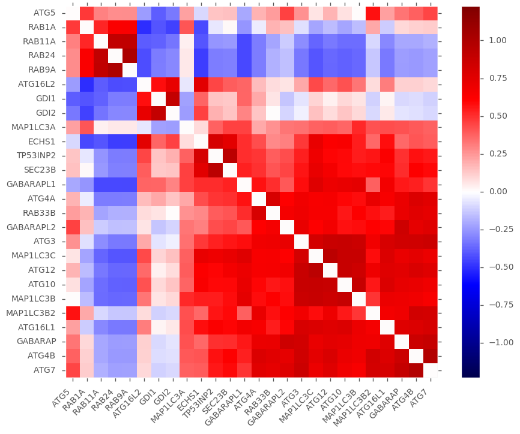

```python
# TODO: retirer cette cellule
S = distance.squareform(1 - distance.pdist(PMIs, metric='cosine'))

plot_symetric_valued_matrix(S, labels=V)
```

### [Positionnement multidimensionnel](https://en.wikipedia.org/wiki/Multidimensional_scaling)

Les protéines sont représentées dans un espace a $n \times N = 9 \times 26 = 234$ dimensions. Pour visualiser le graphe sur un espace 2D, nous allons utiliser la technique du positionnement multidimensionnel. Cet algorithme reconstruit les positions 2D de façon a ce que les distances euclidiennes dans l'espace 2D respectent aux mieux les distances données en entrée, obtenues depuis l'espace a 234 dimensions.

**Q** : Le code suivant (déjà fonctionnel) réalise cet étape avec le paquet `scikit-learn` :

- Est-ce que utiliser notre mesure de similarité (basée sur l'environnement des protéine) est pertinent pour placer les protéines sur une représentation graphique ?
  - Non: deux protéines sont proches lorsqu'elle partagent les même interactions (directement ou indirectement). Cela a tendance a maximiser la longueur des arrêtes et augmenter la probabilités qu'elles se croisent. Les vrais algorithmes de layout ont souvent pour objectif de minimiser le longueur des arrêtes.

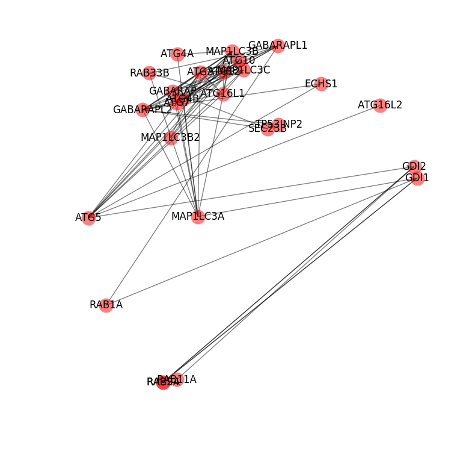

```python
from sklearn.manifold.mds import MDS
plongement = MDS(dissimilarity='precomputed', n_init=64, eps=1e-9).fit_transform(1-S)
nx.draw(G, dict(zip(V, plongement)), with_labels=True, alpha=0.5)
```